# Презентация лабораторной работы

Швецов Михаил Романович

1132236100@rudn.ru

Российский университет дружбы народов

2026-09-02

# Информация

## Докладчик

- **Швецов Михаил Романович**
- студент кафедры теории вероятностей и кибербезопасности
- Российский университет дружбы народов им. П. Лумумбы
- 1132236100@rudn.ru
- https://DarkkLord.github.io/ru/

[figure not shown]

# Выполнение лабораторной работы

Создаём каталог лабораторной работы. (рис. 1).

[figure not shown]

Рисунок 1: Создание каталога:

Устанавливаем все необходимые пакеты (рис. 2).

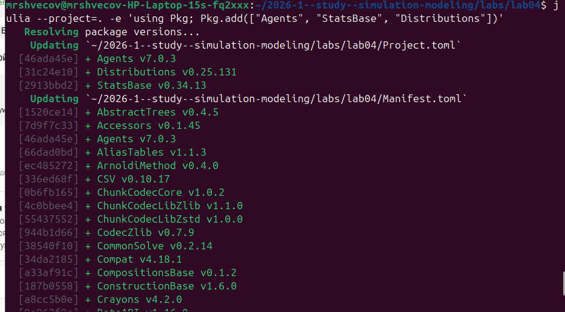

Рисунок 2: Установка:

Далее в каталоге src создаём необходимый скрипт (рис. 3).

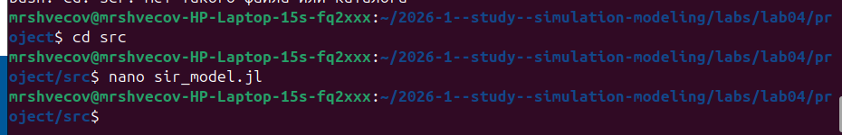

Рисунок 3: Создание скрипта в необходимом каталоге:

Далее создаём необходимый скрипт scripts/sir_run_basic.jl (рис. 4).

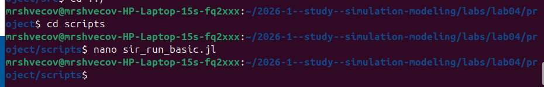

Рисунок 4: Создание скрипта в необходимом каталоге:

Выполнение scripts/sir_run_basic.jl (рис. 5).

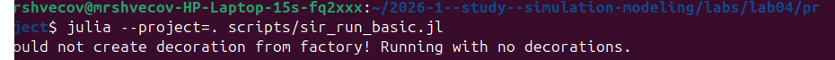

Рисунок 5: Выполнение:

Создание и выполнение скрипта scripts/sir_scan_beta.jl (рис. 6).

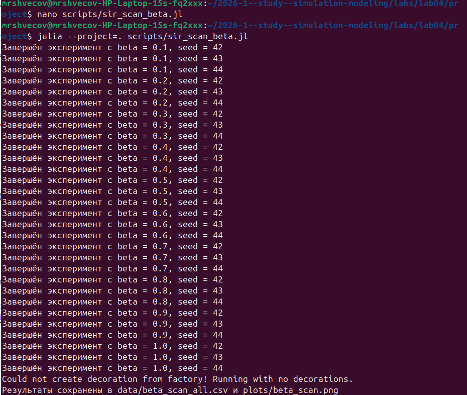

Рисунок 6: Создание и выполнение :

Создание и выполнение скрипта scripts/sir_migration_effect.jl (рис. 7).

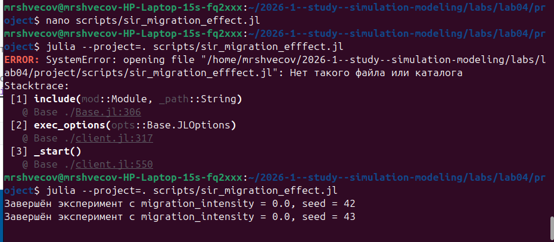

Рисунок 7: Создание и выполнение :

Создание скрипта scripts/sir_optimize_parameters.jl (рис. 8).

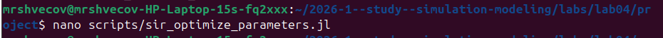

Рисунок 8: Создание:

Загрузим недостающий пакет (рис. 9).

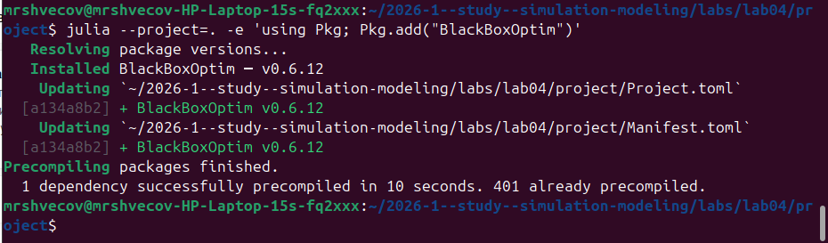

Рисунок 9: Загрузка недостающего пакета

Выполним скрипт scripts/sir_optimize_parameters.jl (рис. 10).

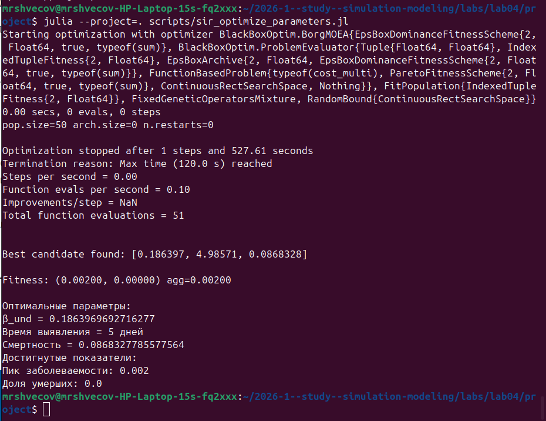

Рисунок 10: Выполнение:

Создание литературного стиля для scripts/sir_scan_beta.jl (рис. 11).

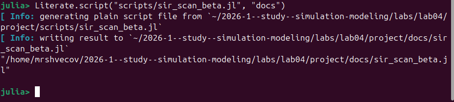

Рисунок 11: Литературный стиль:

Создадим литературный стиль для scripts/sir_migration_effect.jl (рис. 12).

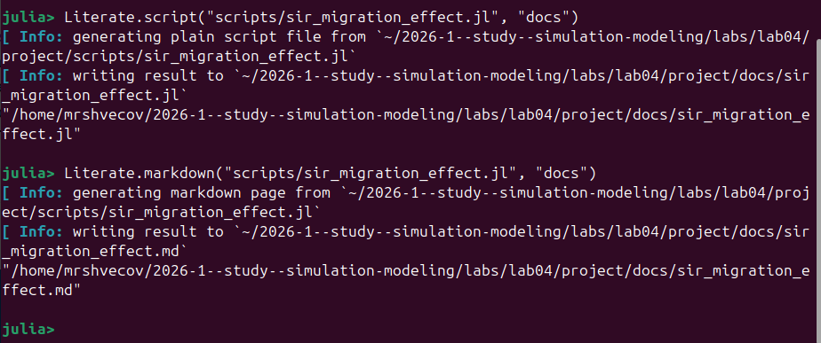

Рисунок 12: Создание литературного стиля:

Создадим литературный стиль для scripts/sir_optimize_parameters.jl (рис. 13).

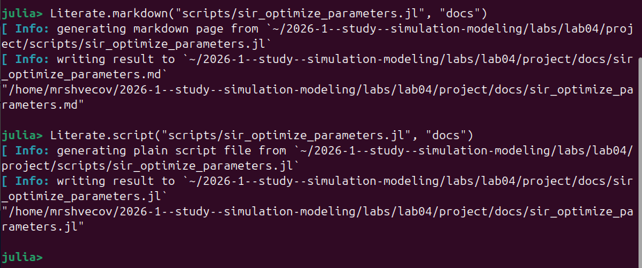

Рисунок 13: Создание литературного стиля:

Создадим литературный стиль для scripts/sir_visualize_dynamics.jl (рис. 14).

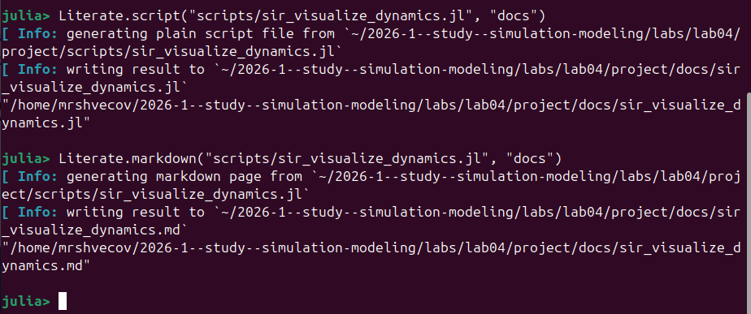

Рисунок 14: Создание:

# Выводы

В данной лабораторной работе мы попрактиковались в создании литературного стиля кода и реализировали модель в агентном подходе на примере Эпидемиологической модели SIR.